# One-way ANOVA Using R

Etana Disasa

6/4/2019

# Introduction

## Data for the Assignment

I am creating three data frames MedTypeA, MedTypeB, and MedTypeC that have the relief scores patients reported (or the number of minutes it took for their pain to subside) as observations.

```r
MedTypeA <- data.frame(ReliefScore=c(14,24,12,25))
MedTypeB <- data.frame(ReliefScore=c(20,14,17,18))
MedTypeC <- data.frame(ReliefScore=c(22,29,36,20))
```

## Exploring Data

```r
MedTypeA; MedTypeB; MedTypeC
```

```
##   ReliefScore
## 1          14
## 2          24
## 3          12
## 4          25
```

```
##   ReliefScore
## 1          20
## 2          14
## 3          17
## 4          18
```

```
##   ReliefScore
## 1          22
## 2          29
## 3          36
## 4          20
```

```r
summary(MedTypeA); summary(MedTypeB); summary(MedTypeC)
```

```
##   ReliefScore
##  Min.   :12.00
##  1st Qu.:13.50
##  Median :19.00
##  Mean   :18.75
##  3rd Qu.:24.25
##  Max.   :25.00
```

```
##   ReliefScore
##  Min.   :14.00
##  1st Qu.:16.25
##  Median :17.50
##  Mean   :17.25
##  3rd Qu.:18.50
##  Max.   :20.00
```

```
##   ReliefScore
##  Min.   :20.00
##  1st Qu.:21.50
##  Median :25.50
##  Mean   :26.75
##  3rd Qu.:30.75
##  Max.   :36.00
```

## Data Preperation

### Stacked Data

Below, I am now creating data frames TypeA, TypeB, and TypeC attaching the prospiective medicine types A, B, C as observations.

```r
TypeA <- cbind.data.frame("A", MedTypeA)
TypeB <- cbind.data.frame("B", MedTypeB)
TypeC <- cbind.data.frame("C", MedTypeC)
colnames(TypeA) <- c("MedicineType", "ReliefScore")
colnames(TypeB) <- c("MedicineType", "ReliefScore")
colnames(TypeC) <- c("MedicineType", "ReliefScore")
TypeA; TypeB; TypeC
```

```
##   MedicineType ReliefScore
## 1            A          14
## 2            A          24
## 3            A          12
## 4            A          25
```

```
##   MedicineType ReliefScore
## 1            B          20
## 2            B          14
## 3            B          17
## 4            B          18
```

```
##   MedicineType ReliefScore
## 1            C          22
## 2            C          29
## 3            C          36
## 4            C          20
```

Here, I am stacking up the three dataframes of 4 observations of each, into a one data frame of 12 observations. You may also notice that I am factoring the first variable (MedicineType).

```r
MyResults_Stacked <- rbind.data.frame(TypeA, TypeB, TypeC)
MyResults_Stacked$MedicineType <- factor(MyResults_Stacked$MedicineType)
MyResults_Stacked
```

```
##    MedicineType ReliefScore
## 1             A          14
## 2             A          24
## 3             A          12
## 4             A          25
## 5             B          20
## 6             B          14
## 7             B          17
## 8             B          18
## 9             C          22
## 10            C          29
## 11            C          36
## 12            C          20
```

```r
str(MyResults_Stacked)
```

```
## 'data.frame':    12 obs. of  2 variables:
##  $ MedicineType: Factor w/ 3 levels "A","B","C": 1 1 1 1 2 2 2 2 3 3 ...
##  $ ReliefScore : num  14 24 12 25 20 14 17 18 22 29 ...
```

### Unstacked Data

From below, we are using the stacked dataframe split into three variables of four observations. When we do a t-test, we will have three variables to evaluate.

```r
MyResults_Unstacked <- data.frame(cbind((MedTypeA), (MedTypeB), (MedTypeC))); colnames(MyResults_Unstacked) <- c("Medication_A", "Medication_B", "Medication_C")
MyResults_Unstacked
```

```
##   Medication_A Medication_B Medication_C
## 1           14           20           22
## 2           24           14           29
## 3           12           17           36
## 4           25           18           20
```

### Performing T-Test

As we perform a t-test, the null hypothesis is that the means of the samples under study are not significantly different. Therefore, the alternative hypothesis then will be the means of the samples are significanly different; thus, the difference is not equal to zero.

H<sub>0</sub>: The mean relief scores reported by the people taking Medicine A, Medicine B and Medicine C are not significantly different.

H<sub>1</sub>: The mean relief scores reported by the people taking Medicine A, Medicine B and Medicine C are significanly different.

Given that we have three data groups, then we will have to do three t-tests of two groups each.

#### 1. T-Test between Scores for individuals treated with Medication A and Medication B

```r
t.test(MyResults_Unstacked[, 1], MyResults_Unstacked[, 2])
```

```
##
##  Welch Two Sample t-test
##
## data:  MyResults_Unstacked[, 1] and MyResults_Unstacked[, 2]
## t = 0.4194, df = 3.819, p-value = 0.6974
## alternative hypothesis: true difference in means is not equal to 0
## 95 percent confidence interval:
##  -8.618444 11.618444
## sample estimates:
## mean of x mean of y
##     18.75     17.25
```

Based on the result, at 95% confidence level, there is no significant difference (p-value = 0.6974) of the two means. Then we fail to reject the null hypothesis that the two means are not significantly different because the p-value is larger than 0.05. The maximum difference of the mean can be as low as -8.62 and as high as 11.62. The output also displays the sample means 18.75 for people that took Medication A, and 17.25 for people who were treated with Medication B.

#### 2. T-Test between Scores for individuals treated with Medication A and Medication C

```r
t.test(MyResults_Unstacked[, 1], MyResults_Unstacked[, 3])
```

```
##
##  Welch Two Sample t-test
##
## data:  MyResults_Unstacked[, 1] and MyResults_Unstacked[, 3]
## t = -1.6176, df = 5.9601, p-value = 0.1572
## alternative hypothesis: true difference in means is not equal to 0
## 95 percent confidence interval:
##  -20.120934   4.120934
## sample estimates:
## mean of x mean of y
##     18.75     26.75
```

Here at 95% confidence level, there is no significant difference (p-value = 0.1572) of the two means. Then we fail to reject the null hypothesis that the two means are not significanly different because the p-value is larger than 0.05. The maximum difference of the mean can be as low as -20.12 and as high as 4.12. The output also displays the sample means 18.75 for people that took Medication A, and 26.75 for people who were treated with Medication C.

#### 3. T-Test between Scores for individuals treated with Medication B and Medication C

```r
t.test(MyResults_Unstacked[, 2], MyResults_Unstacked[, 3])
```

```
##
##  Welch Two Sample t-test
##
## data:  MyResults_Unstacked[, 2] and MyResults_Unstacked[, 3]
## t = -2.4701, df = 3.6989, p-value = 0.07406
## alternative hypothesis: true difference in means is not equal to 0
## 95 percent confidence interval:
##  -20.529876   1.529876
## sample estimates:
## mean of x mean of y
##     17.25     26.75
```

Here at 95% confidence level, there is no significant difference (p-value = 0.07406) of the two means. Then we fail to reject the null hypothesis that the two means are not significanly because the p-value is larger than 0.05. The maximum difference of the mean can be as low as -20.53 and as high as 1.53. The output also displays the sample means 17.25 for people that took Medication B, and 26.75 for people who were treated with Medication C.

### Plotting Results

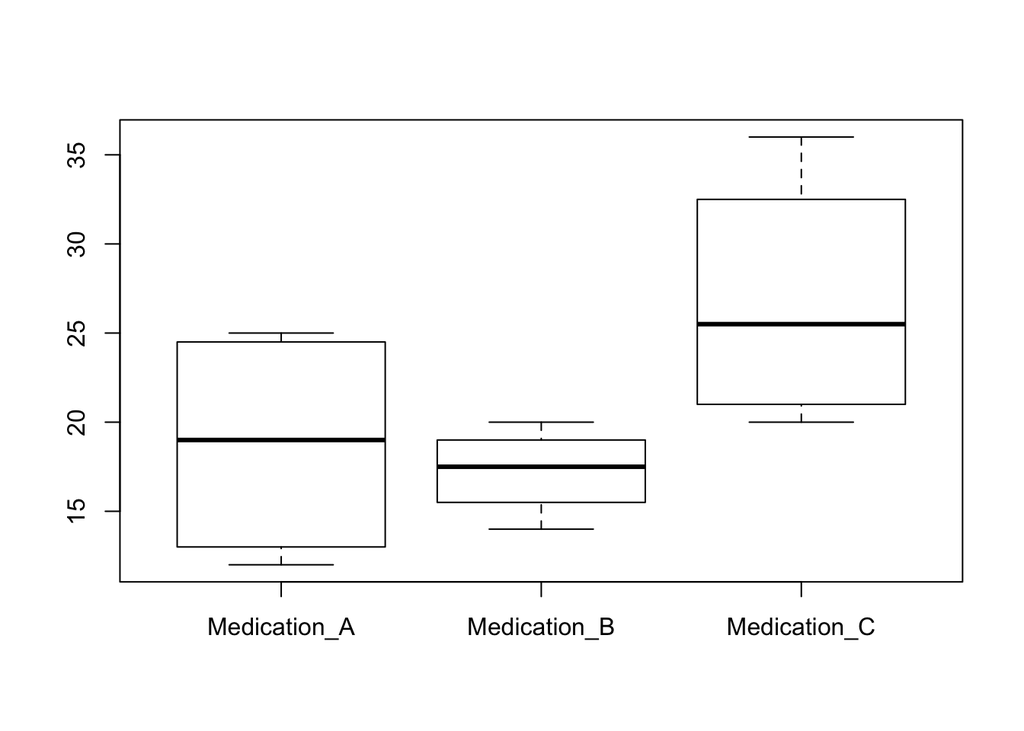

```r
boxplot(MyResults_Unstacked)
```

### ANOVA Test

```r
MyResults <- lm(ReliefScore ~ MedicineType, MyResults_Stacked)
summary(MyResults)
```

```
##
## Call:
## lm(formula = ReliefScore ~ MedicineType, data = MyResults_Stacked)
##
## Residuals:
##    Min     1Q Median     3Q    Max
## -6.750 -4.750  0.250  3.375  9.250
##
## Coefficients:
##               Estimate Std. Error t value Pr(>|t|)
## (Intercept)     18.750      2.945   6.367  0.00013 ***
## MedicineTypeB   -1.500      4.165  -0.360  0.72705
## MedicineTypeC    8.000      4.165   1.921  0.08695 .
## ---
## Signif. codes:  0 '***' 0.001 '**' 0.01 '*' 0.05 '.' 0.1 ' ' 1
##
## Residual standard error: 5.89 on 9 degrees of freedom
## Multiple R-squared:  0.4006, Adjusted R-squared:  0.2674
## F-statistic: 3.007 on 2 and 9 DF,  p-value: 0.09995
```

Below, we are running the ANOVA test using the results of our linear model to see the findings. Our null and alternative hypotheses are:

H<sub>0</sub>: There is no significant difference in the means among the different factors of the independant variable.

H<sub>1</sub>: There is a significant difference in the means among the different factors of the independant variable.

```r
anova(MyResults)
```

```
## Analysis of Variance Table
##
## Response: ReliefScore
##              Df Sum Sq Mean Sq F value  Pr(>F)
## MedicineType  2 208.67 104.333  3.0072 0.09995 .
## Residuals     9 312.25  34.694
## ---
## Signif. codes:  0 '***' 0.001 '**' 0.01 '*' 0.05 '.' 0.1 ' ' 1
```

As a result the p-value here is 0.09995 which is > 0.05 with a 95% confidence level. Thus, we fail to reject the null hypothesis. In other words, there is not significant difference in the means among the different factors of the independant variable.

# Conclusion

In conclusion, the t-test was performed on the unstacked data to see if the means between the different variables are significantly; and the ANOVA test on the stacked data to see if the means for all groups is not signficantly different. Both tests returned similar results which is the means are not signficnatly different from each other. Thus, as a conclusion to this assignment, the tests had assisted us in determining that there does not seem to be a statistically significant difference in the means (average) time of relief between using Medication A, Medication B or Medication C.

# References

Mintab Blog Editors. (n.d.). Understanding t-Tests: t-values and t-distributions. Retrieved June 11, 2019, from https://blog.minitab.com/blog/adventures-in-statistics-2/understanding-t-tests-t-values-and-t-distributions

Stats: One-Way ANOVA. (n.d.). Retrieved June 11, 2019, from https://people.richland.edu/james/lecture/m170/ch13-1wy.html